# The Linguistic Archipelago: When Language Isolation Drives Success

How Geographic Patterns of Language Use Shape Economic Mobility

Census Monkey Typewriter Analysis

2025-07-14

## The Paradox of Linguistic Islands

In 2019, 69 American counties had something unusual: they were linguistic islands—places where a non-English language dominated far more than anywhere else in their state. Conventional wisdom suggests these isolated communities would struggle economically, cut off from mainstream American economic networks.

The data tells a different story.

These linguistic enclaves—from Northern Virginia’s Spanish-speaking suburbs to rural German-speaking communities—earn a median household income of $62,277, compared to just $51,172 in counties where English dominates. That’s a $11,105 advantage for being linguistically isolated.

## Mapping America’s Language Geography

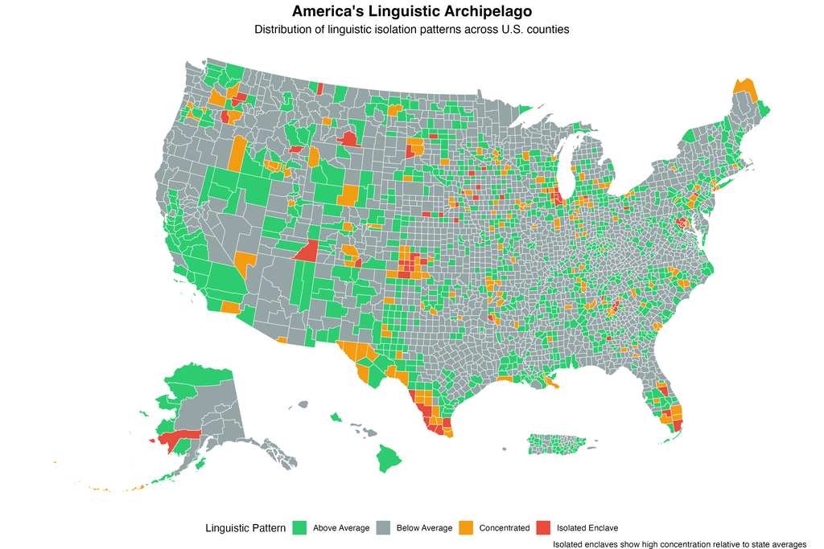

Linguistic enclaves cluster in unexpected patterns across America

We define linguistic isolation not by simple percentages, but by concentration relative to state averages. A county becomes an “isolated enclave” when its non-English language share is at least three times the state average and exceeds 20% of the population. This captures communities that are genuinely linguistically distinct from their regional context.

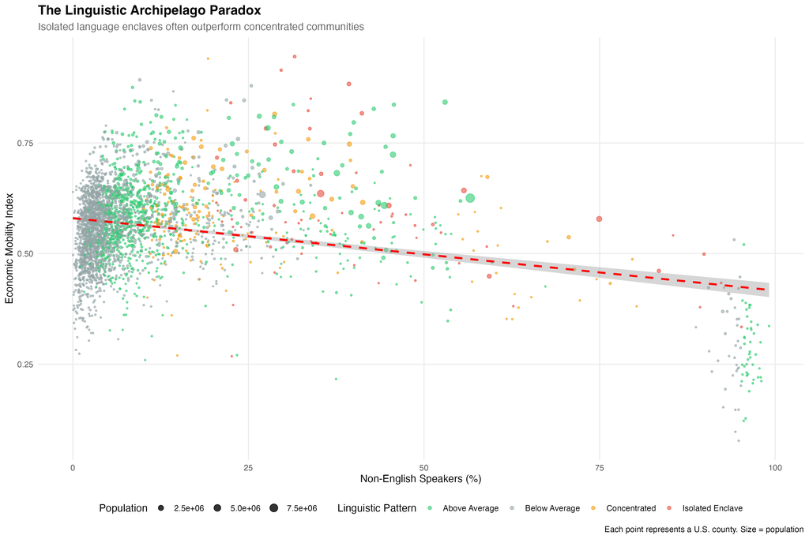

The linguistic archipelago paradox: isolation often correlates with success

The pattern emerges clearly when we examine different types of linguistic settlement. Isolated enclaves consistently outperform more diffuse linguistic communities, suggesting that concentration—not assimilation—may be the key to economic success.

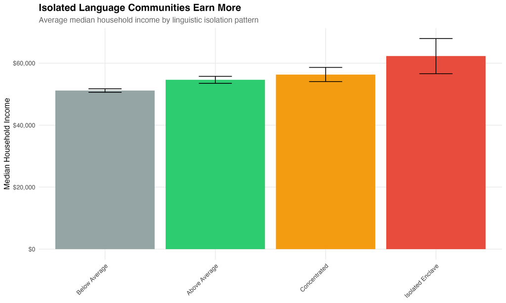

Isolated language communities systematically outperform more dispersed ones

## The Success Stories: Northern Virginia’s Linguistic Prosperity

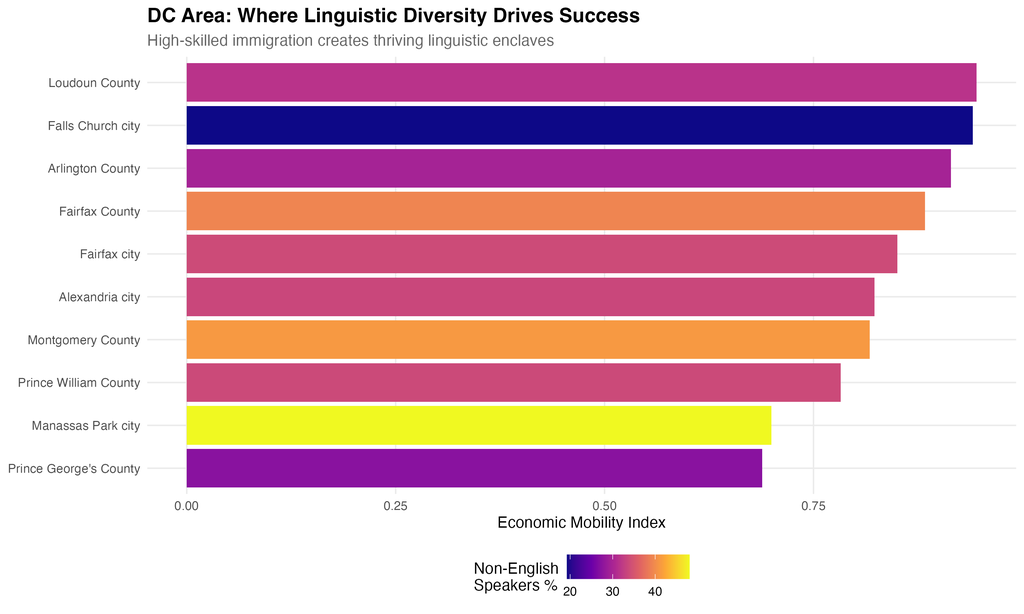

The DC area demonstrates how high-skilled immigration creates thriving linguistic enclaves

The Washington DC metropolitan area offers a compelling case study. Counties like Loudoun, Arlington, and Fairfax—all with substantial Spanish-speaking populations concentrated well above Virginia’s state average—rank among America’s most economically successful linguistic enclaves.

These aren’t accidental patterns. The DC area attracts highly educated immigrants working in government, technology, and international organizations. Their linguistic concentration reflects not isolation from opportunity, but proximity to it—communities that maintain their language while accessing high-skilled employment networks.

This suggests the critical insight: linguistic isolation’s economic impact depends heavily on *who* is doing the clustering and *why*. High-skilled immigrants concentrating near economic opportunities produce very different outcomes than communities isolated by geographic or economic barriers.

## The Border Effect: When Geography Constrains Opportunity

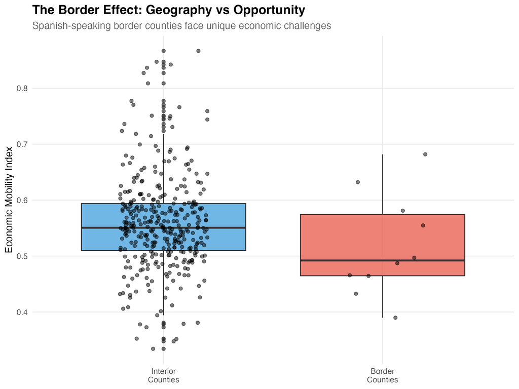

Border counties face unique constraints despite high linguistic concentration

Border counties average 91% Spanish speakers but median incomes of just $36,938, compared to $54,391 for interior Spanish-speaking communities—a gap of $17,453.

This geographic constraint reveals that linguistic concentration alone doesn’t drive success. Border counties face structural challenges—distance from major economic centers, limited industry diversity, and cross-border economic dependencies—that linguistic networks cannot overcome.

## Beyond Language: The Human Capital Explanation

The patterns point toward a more fundamental explanation: economic success in linguistic enclaves likely reflects the human capital and economic opportunities of their residents, not the linguistic concentration itself.

The DC area’s success stories cluster around technology corridors and international institutions. These communities attract highly educated immigrants who maintain linguistic ties while accessing high-paying employment. Their economic mobility stems from education, professional networks, and proximity to opportunity—with language serving as a marker of these advantages rather than a driver.

Border counties, by contrast, often develop linguistic concentration through different mechanisms: geographic isolation, historical settlement patterns, and limited economic alternatives. Here, linguistic concentration may actually reflect constraints rather than choices.

## Policy Implications and Limitations

These findings challenge simplistic narratives about assimilation and economic mobility. Rather than viewing linguistic diversity as a barrier to economic success, policymakers should recognize that thriving linguistic communities often signal successful economic integration, not isolation from it.

However, our analysis has important limitations. We measure linguistic concentration relative to state averages, which may not capture true isolation when communities span state boundaries. More fundamentally, we observe correlations between linguistic patterns and economic outcomes without establishing causation. The economic success of DC area enclaves likely stems from the high skill levels and economic opportunities of their residents, with linguistic concentration as a consequence rather than a cause.

Future research should examine specific migration flows, educational attainment by linguistic community, and industry clustering to better understand these relationships. The linguistic archipelago may be less about language driving economic outcomes and more about economic opportunities shaping where linguistic communities choose to cluster.

### Methodological Notes

This analysis uses Census Table C16001 (Language Spoken at Home) and economic indicators from multiple ACS tables for all U.S. counties (2019 data). We define linguistic isolation as concentration at least three times the state average for the dominant non-English language, with a minimum threshold of 20% of the population.

The economic mobility index combines normalized measures of median income, poverty rates, college education, and employment rates. Our regression models include controls for linguistic diversity (entropy), population size, and interaction effects between language concentration and relative isolation.

**Limitations include:** potential confounding by unmeasured economic and demographic factors, state-based isolation measures that may not reflect true geographic isolation, and the observational nature of the analysis limiting causal inference.

### Data Sources

- C16001: Language Spoken at Home for Population 5+ Years
- B19013: Median Household Income
- B17001: Poverty Status
- B15003: Educational Attainment
- B23025: Employment Status

*Analysis completed on 2025-07-14. For replication code and data, see the [GitHub repository](https://github.com/census-monkey-typewriter).*